# Abstract

## Functional traits and niche differentiation

Phenotypic differences among species impact diversity in communities (MacArthur and Levins 1967). In the rules of community assembly, functional traits provide insight into co-occurring species’ ecological strategies. McGill et. al (2006) posit that functional traits are one of four major themes governing the composition of a species’ fundamental and realized niches (the others being environmental gradients, interaction milieu, and performance currency). Functional traits have become a useful tool in understanding the nature of the relationship between plants within their communities, as well as understanding the relationship between environment and community assembly. By examining functional traits, we can more fully understand the resource partitioning within niches.

To more fully understand plant responses to environment, functional traits serve as useful predictors of traits that are more difficult to measure but provide better projections of success. For example, certain seed sizes and shapes strongly correlate with persistence of the seed in soil (Thompson et. al 1993). These studies have seen subtle differences in strategy differentiation contributing to species coexistence. Additionally, a large amount of intraspecific variation in functional traits may reduce the effect of phylogenetic relatedness in nearby species (i.e. limiting similarity) (Burns & Strauss 2012). Kraft et. al (2008) showed that species with a broad distribution of trait values co-occur more often than expected by a null model, indicating that variable trait patterns enable more co-occurrence of species within a community. Similarly, certain suites of functional traits can enable individuals to be more successful than others of the same species under environmental conditions that favor those traits (Jung et. al 2010). Additionally, intraspecific variation in physiological traits may give species the chance to survive in the face of rapid climatic changes within their range (Davis & Shaw, 2001; Nussey et al., 2005; Skelly et al., 2007).

Functional traits have also been shown to be accurate predictors of species’ geographic ranges (Stahl & Wirth 2014), lending credence to the theory of niche differentiation and resource partitioning as a primary factor in determining a species’ geographic range. The functional traits of a species across its range can thus provide valuable information about the biotic and abiotic factors that limit it beyond its range, and how it is responding to those limiting factors. By using functional traits to describe a plant’s resource partitioning across its geographic range, I can more accurately predict how a species could respond to shifts in climate. Incorporating trait-based models in our understanding of the roles that species interactions play in community assembly is crucial (Pigot & Tobias 2013).

Different functional traits correspond to varying plant functions. This is described by Grime’s CSR Triangle, or Grime’s ‘plant strategy theory’ (Grime 1974). There triangle is divided into the C–S axis, representing adaptation to opportunities for rapid growth versus continuing enforcement of slow growth (Competitors to Stress-tolerators), and the R-axis – reflecting adaptation to disturbance (Ruderals). Specific Leaf Area (SLA) provides a ratio of the light-capturing area deployed (leaf area) per dry mass allotted by the plant. The nutrients of tissues in plants also serve to provide information on resource investment. The ratio of carbon to nitrogen in a leaf gives information on the life history strategy of the leaf, as well as relative investment in the structures of the plant that harvest light. The height of a plant is an indicator of its local performance, while stem specific density provides insight into drought resistance and/or growth rate.

## Range shifts and response to climate change

Observing a species at its range edge can help test the conditions by which some populations adapt successfully (or not) to novel conditions. Based on the niche conservatism hypothesis, when environmental conditions stretch beyond a species’ physiological tolerances, that species will either shift its distribution or face extinction (Peterson, Soberón, & Sánchez-Cordero 1999). More specifically, in response to a changing environment, a population may respond one of a few ways: 1) local population changes in microhabitat or altitudinal distribution; 2) large-scale shifts in geographic distribution, consisting of range expansions and range contraction in the former range; 3) adaptive evolution of the niche in response to the new conditions; and 4) extinction (Ackerly 2003; Thomas, Franco & Hill 2006).

Yet on their southern range edges, species are faced with possible extinction with climate change. In a study observing the distributional shifts of Silene acaulis (moss campion) and the geophyte Polygonum viviparum (alpine bistort) across six years, both populations saw die-out at their southern range edge (Doak & Morris 2010). The same effect has been seen earlier in history. As the temperature increased late in the last glacial interval, woody species populations established themselves at increasingly higher latitudes in so-called “migrations” (David & Shaw 2001). To compensate for population loss at their southern edge due to the loss of their preferred environment, a species must shift northwards. Evidence shows that this shift may not occur quickly enough to account for the rate of changing temperatures and population loss. In a meta-analysis of plant distributions spanning 40 years, Bertrand et. al (2011) found a lag in the responses of herbaceous forest species to climate change. Since species often track their optimal environment (Ackerly 2003), strong limiting factors due to competitiveness may indicate that a species will not be able to migrate at a rate sufficient to account for population loss at their southern range edge.

In addition to shifts in distribution, there is evidence that plant species underwent local adaptation (genetic) in response to changing climates over the last 10,000 years (Davis & Shaw 2001). Yet populations are unlikely to undergo local adaptation at the pace necessary to match many current changes. Such changes include the invasion of competitors from adjacent positions and climate change (Ackerly 2003). Further, competition has been shown to hinder the advancement of colonists into new environments during shifts due to changing environments (Suttle, Thomsen & Power 2001; Urban et. al 2012). This limits a species’ options in terms of biotic factors. Simultaneously, the speed of climate change affects how prevalent adaptive responses are (Ackerly 2003). Species are left with only one option: to migrate.

Work across species range extremes and range interiors, such as the work that I have conducted, allows us to see whether a species is primed to migrate, and how many limiting factors it might face during migration, given its decreasing preferred climatic envelope. Because edge populations may see more variability in survival and reproduction due to the frequency at which they must respond to limiting factors (Reich & Oleksyn 2008; Sexton et. al 2011), range extremes are a unique opportunity to understand current modes of community assembly, as well as to predict species’ future responses to climate change.

## Latitudinal gradients as field laboratories

The study of range expansions and retractions is best accomplished through studies across latitudinal gradients. Using a latitudinal gradient as a study system allows for observations of a species across a larger spatial scale than in warming facilities, and provides a much more accurate representation of the habitat that either allows or prevents a species from establishing itself (De Frenne et. al 2013). Generally, there is a reliable poleward decrease in temperature across latitudes. On average, temperature decreases approaching the poles on the order of -0.73 C per degree latitude in the Northern hemisphere. Other climatic variables, such as precipitation, also change across latitudes (De Frenne et. al 2013). Looking at species’ traits and community composition across latitudes can provide insight into the effect of environmental variables on range limits and species’ future success.

Many recent studies use altitudinal gradients as a predictor of species’ responses to climate change in lieu of latitudinal gradients, likely due to the relative ease of collection relative to sampling across latitudes (Matías & Jump 2015). Altitudinal gradients have a much smaller rate of spatial change in temperature as compared to latitudinal gradients (Jump et. al 2009). This further increases the chances that local adaptation will successfully occur due to genetic drift (Davis & Shaw 2001).

Recording a species’ functional traits and community composition across a latitudinal gradient provides a proxy for understanding how that species will respond to warming temperatures in its range exterior. Because the observed pattern of range shifts is up and poleward, studying a species across its latitudinal range provides important information about the effect of biotic and abiotic interactions that might decrease the possible rate of migration for a species. Latitudinal gradients are thus an apt study system with which to integrate species interactions and environmental stressors as predictors of a species’ future distributions with regards to climate change.

## Predictions and hypotheses

To determine the nature of woody species’ future responses to climate change, I sampled six species of woody deciduous trees across four different sites on a latitudinal gradient in the northeastern United States and into Quebec. I predicted that:  
**H1:** a species would become less competitive as they approached its latitudinal and climatic range limits, since populations at geographic range edges more frequently experience strong, limiting factors (Sexton et. al 2009).  
**A1:** Alternatively, a species could grow more competitive as it approaches its range limit due to a mix of possible factors (e.g., the presence of fewer competitors, or increasing competitive ability of species at the abiotic environment of the edge etc.), thus leading to a greater realized niche.  
**A2:** Finally, it is a possibility that competition is not predicted by position in its climatic or latitudinal range, indicating that local factors, such as habitat or resource availability, might matter more within each population. Similarly, other factors could determine competitiveness, such as community composition and local adaptation, rather than a species’ position within its range limit. It is possible that local community composition around each tree is most predictive of its competitive success, with little overall pattern across the latitudinal gradient. Looking at a woody species’ competitiveness across a latitudinal gradient provides information into the part that biotic factors play in its realized niche, and the possible effects of those biotic factors in a warming environment.  
**H2:** I also predicted that trees at their range extremes would exhibit altered suites of functional traits from trees in the range interior (Weiher & Keddy 1998). Similar to the prediction (H1) above, because populations at their range limits often see more extreme environments, I predicted that their functional traits would exhibit altered plasticity compared to functional traits of individuals at their range interiors. Studies have shown that a species’ functional traits that are linked to life strategies vary based on the latitude of their origin (Cavender-Bares 2007).  
**A1:** Increases in intraspecific trait variation across a latitudinal gradient at the range limit would indicate increased genetic adaptation and/or increased plasticity. Since populations at their range extremes (and at more northern latitudes) face harsher environments than populations in their range interior, this could be due to a plant’s attempts to limit its phylogenetic similarity in the face of competitors in a sub-optimal environment, or simply because it is exhibiting greater plasticity in response to the more extreme environment.  
**A2:** Alternatively, decreased intraspecific trait variation approaching a range limit would indicate that only one combination of traits is successful in that particular limiting environment (Burns & Straus 2012).  
**A3:** Finally, no clear pattern in intraspecific variation in functional traits approaching the range limit of a species would indicate that other rules of community assembly are playing a larger part in the determining of range limits, such as competition or other biotic factors.  
By examining community composition of certain woody species in conjunction with their corresponding functional traits across this latitudinal gradient, we can better predict how species composition will change at the forest level. In looking at both the community composition of species at these sites and their functional traits specifically at the range limits, we can understand which species are most at risk with the changing environment, and why they might not survive.

Here I report on a study to test these hypotheses (H1 and H2) by examining six woody species with individuals across their latitudinal ranges. I will evaluate (a) the effect of latitude on six woody species’ competitiveness indices and functional traits and (b) the effect of distance from a species’ preferred environment on the species’ competitiveness indices and functional traits.

# Methods

To understand community composition and functional traits in response to range limits, I examined the immediate vicinity of six deciduous tree species. I collected data on the community composition of the understory species, as well as current competitive environment for each focal tree. Data on functional traits for some of the same individuals were collected the year prior across all four sites through the summer.

## Sites

I collected data at four sites, all spaced approximately one latitudinal degree apart from each other. Individuals of the six species had previously been tagged for past lab work. All sites were temperate deciduous forests with a small amount of human disturbance. The southernmost site was Harvard Forest, an LTER in Petersham, Massachusetts. The Harvard Forest spans approximately 3000 acres, and lies 110 kilometers west of Boston. The second site was located in the southern White Mountains in New Hampshire, off the Kancamagus Highway. As the southernmost part of the White Mountains, the site does not lie within a protected research area. However, as part of a national forest, it is fairly protected from human intrusion. The third site was in the Dartmouth College Second Grant, a site maintained by Dartmouth College for logging, recreational use, and scientific research. The Grant in northern New Hampshire, near the border of Maine. Finally, the northernmost site was located at the Station de biologie des Laurentide in Quebec. The Station de biologie des Laurentide is slightly larger than Harvard Forest, spanning 4000 acres, and is 75 kilometers northeast of Montreal. Due to the varying latitudes, the northern-most sites see a climate of colder winters and shorter growing seasons. All follow mild summers.

All four sites had previously been used by the Wolkovich lab for research in temporal ecology into the species used for this experiment, thus ensuring the presence of suitable individuals at each site. Nearly all sampling sites occurred in closed canopy forests, except for some sampling plots of Cornus alternifolia and Sorbus americana which frequently appear on forest edges.

## Species Selection

I sampled six different species of deciduous woody plants that are abundant across the latitudinal range of our sites in the Eastern US. The species’ ranges vary, though all reach a range extreme near one of our four sites. The species in question are: Acer pensylvanicum, Betula papyrifera, Cornus alternifolia, Fagus grandifolia, Hamamelis virginiana, and Sorbus americana. Four of the six species reach their northern range extremes within or just outside of the latitudinal range covered by the four study sites. Two species, Betula papyrifera and Sorbus americana, reach their southern limits just below the southern-most site at Harvard Forest. Hamamelis virginiana, on the other hand, reaches its northern limit near our second southern-most site in the White Mountains.

Each species was selected based on (a) which species had been included in past studies at the four sites as part of the Wolkovich lab’s work, and (b) the location of its range limits with relation to the four sites. I found each species’ latitudinal range limits through the websites bonap.org, plants.usda.gov, and gbif.org. This was to account for records of tree species that were recorded outside their latitudinal limits (as evidenced by highly decreased abundance), but had still been recorded as appearing in different counties.

## Competition and community data

For each of the six species, I tagged six (or found some previously tagged) individuals at each site that the individuals were present in. I compared total basal area of the focal individual with trees in the competitive environment around each focal individual. The direct competitive environment was estimated as being within a 5-m radius around the focal tree. I recorded the DBH of all trees falling within this circle. I took note of the presence and absence of species in the understory, including species of saplings appearing under 1.3m. To determine competitiveness of our focal individuals, I used the percentage of total basal area attributable to the focal individuals as a proxy for competitive advantage in each plot.

Competition index was calculated according to methods outlined in Biging and Dobertin (1995). I calculated the sum of the trees larger than the focal tree, and took the ratio of the basal area of the focal tree to this sum. By using relative basal area, the trend of decreasing DBH as species increase in latitude would not show in the model.

## Climate data

Climatic centroid data was derived from data from the 30 arc-second WorldClim database (the highest resolution, available at http://www.worldclim.org/) across each species’ recorded distributions. Once the data was downloaded, it was then averaged within an equal area grid of 50km^{2}. The variables used to compute the climatic envelope in multi-dimensional space were average temperature (BIO1 Raster), mean diurnal range (BIO2 Raster), temperature seasonality (BIO4 Raster, akin to standard deviation*100), and annual precipitation (BIO12 Raster). This data was then used to calculate the climatic envelope by conducting a principal components analysis on the bioclimatic variables used. These two axes were then averaged for each species to find the coordinates of the climatic centroid. I then quantifed the distance from the climatic centroid and each of the focal individuals used in the study based on a climatic envelope specific to their species and their species’ distribution. This was done through the formula for euclidean distance, putting in the coordinates of the climatic centroid and the coordinates of the location of each individual at its point in climatic space.

## Functional Traits

For functional trait data, I used the data collected the previous summer by Harry Stone during the Harvard Forest REU Summer Program in 2015. The height of individuals not measured summer 2015 was measured through a clinometer. Additionally, I measured the Diameter at Breast Height (DBH) of any newly-tagged individuals (in cases where an individual is too close to another focal plant). Functional traits for newly-tagged individuals were not measured, but instead the traits measured in 2015 served as a representation of the traits of all species within that site.

Data on the functional traits Specific Leaf Area (SLA), Leaf N%, leaf dry matter content, and height were all collected for at least six individuals of the six species across the four sites (when applicable). Samples were processed in the John Torrey laboratory at the Harvard Forest. When possible, leaf samples were collected near the center of the tree canopy. Leaf size was measured using the LI-COR 3100 leaf area meter. To account for variation within an individual, a wide range of leaf sizes were measured to achieve a representative average size. Specific leaf area (SLA) was determined by the leaf size divided by dry mass of the leaves (Cornelissen 2003). The leaves were weighed after drying for than 24 hours at 60 OC.

Harry Stone and colleagues measured leaf dry matter content by comparing the fresh mass of the leaves, determined immediately after removal from the individual and the dried weight. Height of the individual was measured using a clinometer from 15 meters away from the tree. Stem specific density was measured by comparing the volume of the stem sample to the dried mass. The volume of the stem was calculated by submersion in a container of water and the volume of the water displaced is equivalent to the volume of the stem. Then the stems were dried in excess of 24 hours in the drying oven at 60 OC.

# Results

The species composition across the four sites, as evidenced by the multi-dimensional scalar plots (Fig. 1), shows a marked difference between the species compositions of Harvard Forest and the other three sites. This is mirrored in both the overstory and understory species composition, suggesting that the type of competition seen by the deciduous trees present in Harvard Forest may differ from that of the other three sites. The multi-dimensional scalar plots show the differences in combinations of species, meaning that the three overlapping convex hulls (representing the White Mountains, the Grant site, and St. Hippolyte in increasing latitudes) saw very similar combinations of species in both the overstory and the understory, whereas Harvard Forest saw very different combinations of species from the other three sites. The plots are dimensionless, and serve to represent the convex hull of unique combinations of species. For example, a larger polygon would indicate more unique combinations of species present (such as in the White Mountains site), whereas the Grant plot sees a smaller diversity of species combinations. The understory in general was composed of smaller diversity of species combinations as compared to the overstory.

# Figures

(should I include this? I can make it higher resolution)

## Figure

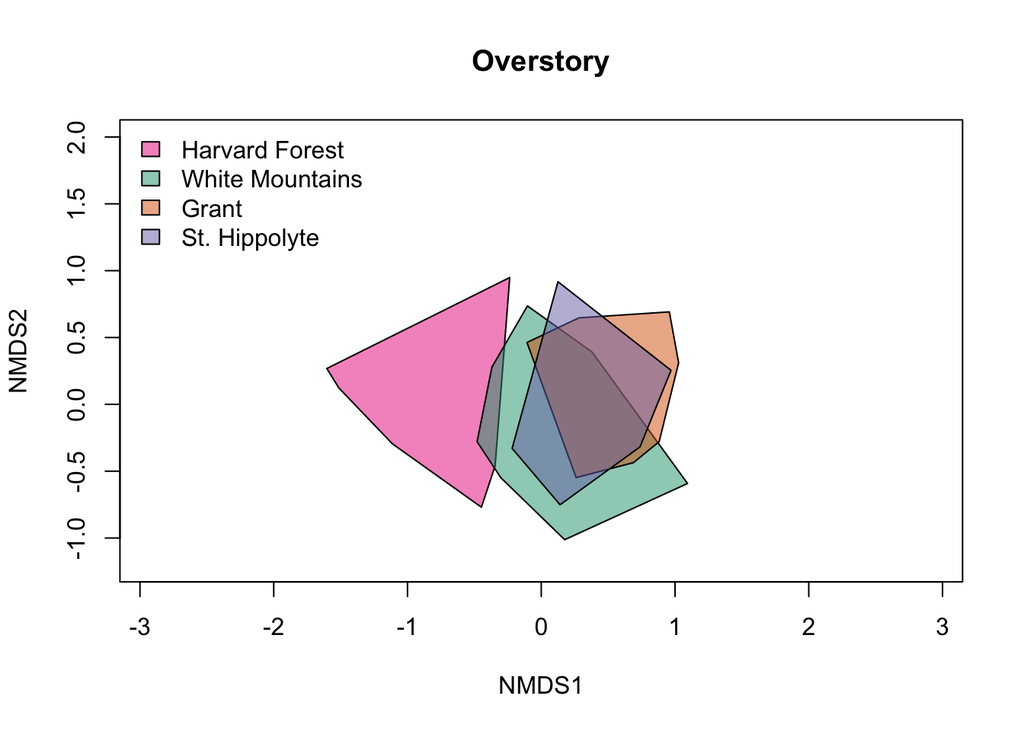

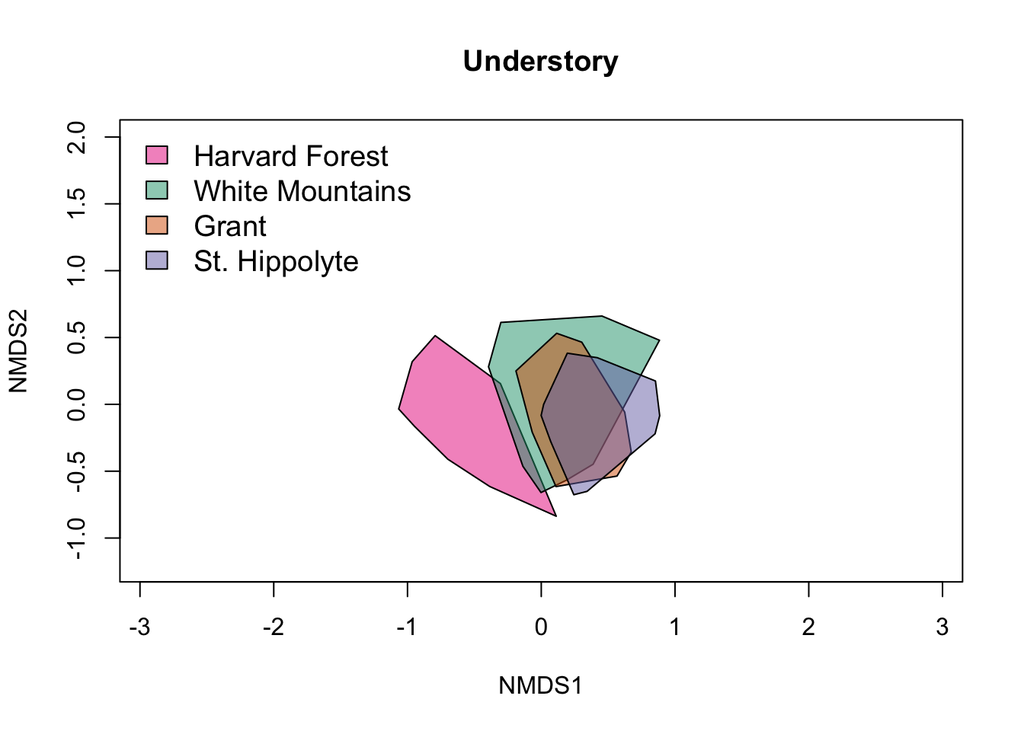

## Figure 3

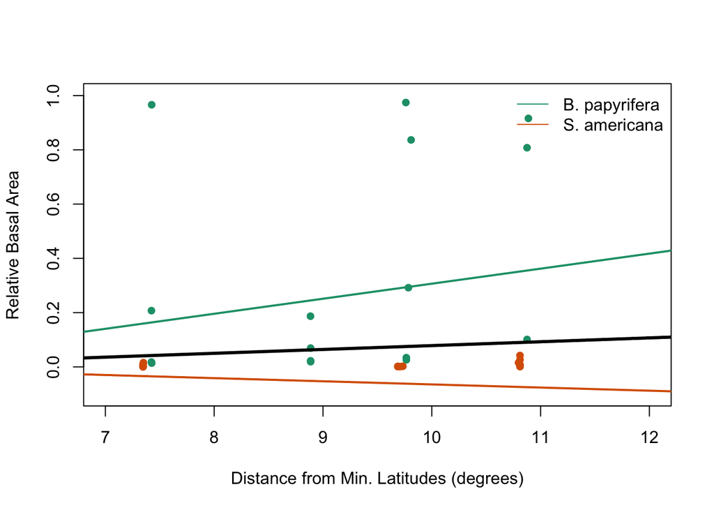

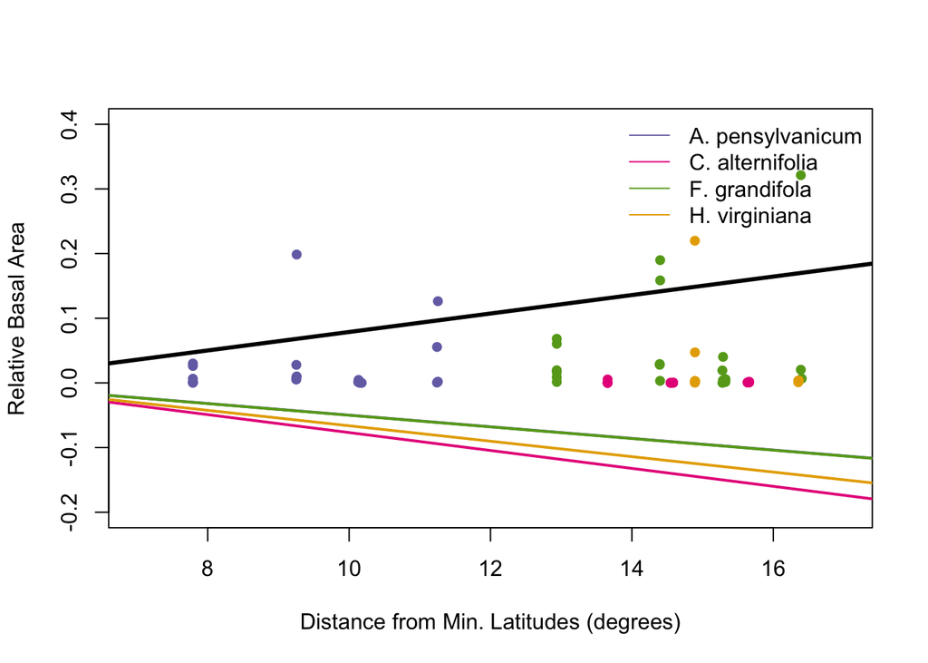

## Figure 4

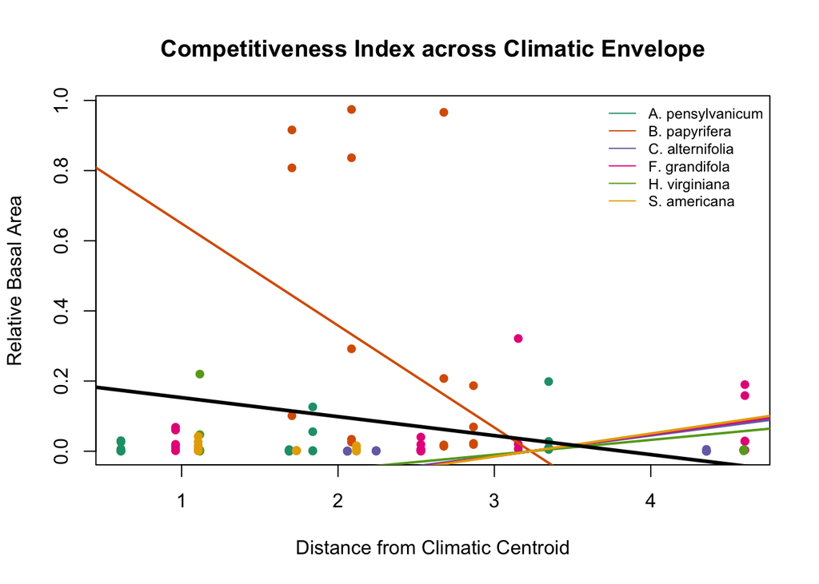

## Figure 5

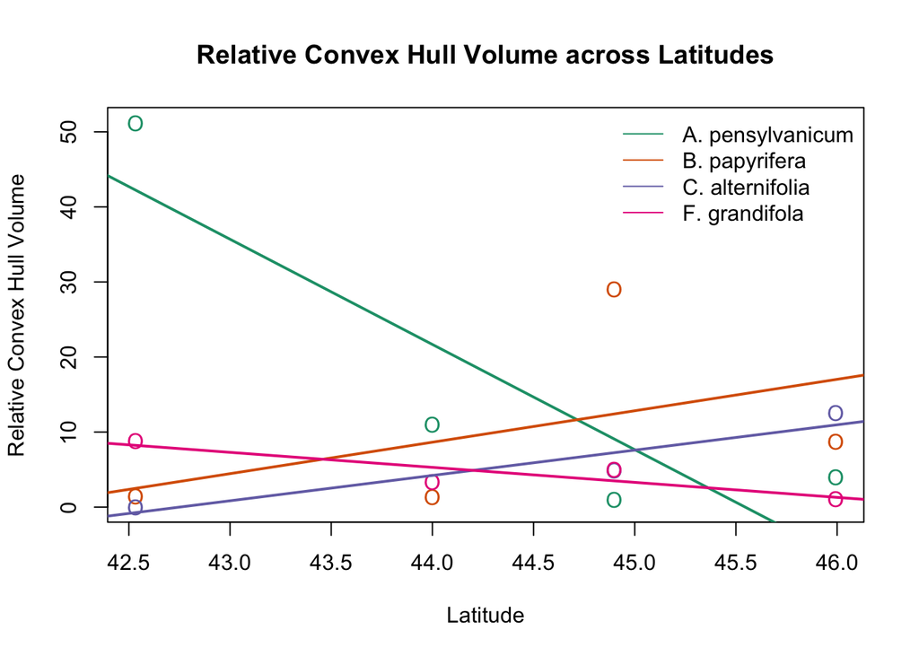

## Figure 6

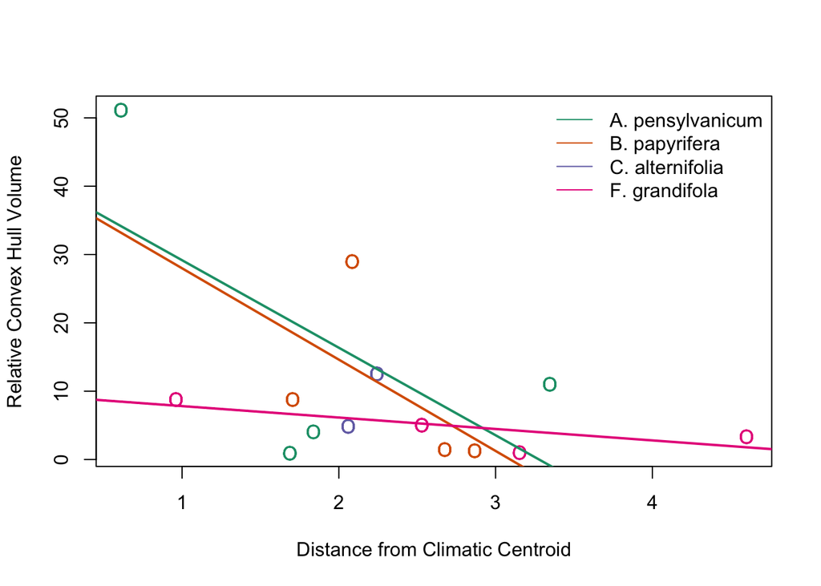

## Figure 7

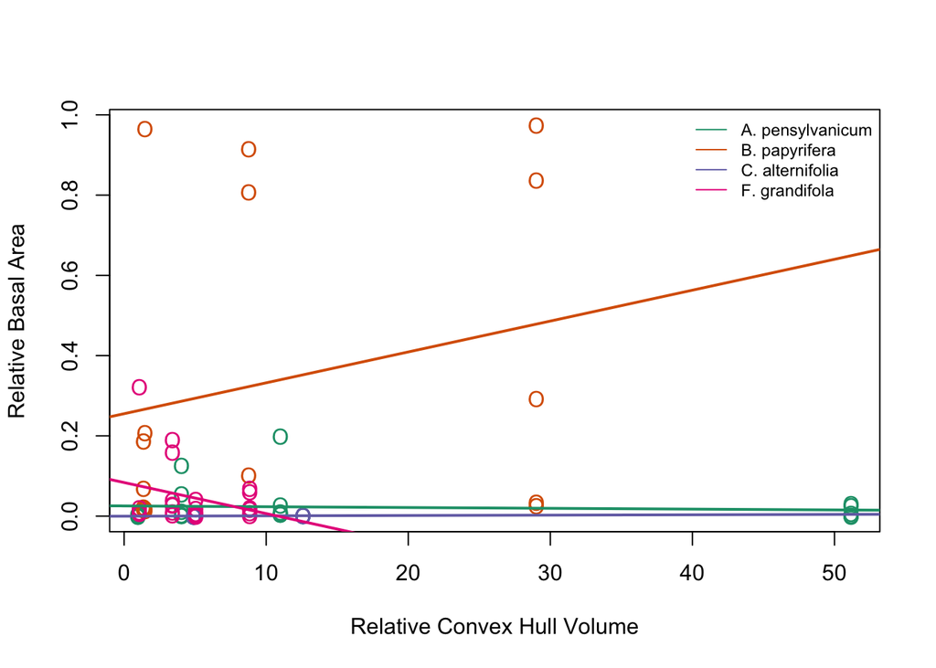

# Discussion

Ecologists have long understood that range limits are caused by complex dynamics between biotic and abiotic factors. These dynamics are especially important to understand in light of climate change. A warming world and shift in abiotic factors necessitates research into the limiting effect of biotic interactions at range limits. As a species’ climatic envelope migrates north, looking at the limiting power of biotic and abiotic factors can provide insight into the future survival of that species. My results suggest that the effect of biotic and abiotic factors on limiting trees at their range limits varies across tree species. They showed no clear pattern with regards to a species’ competitiveness across latitudes or climatic envelopes, even within species positioned closer to their southern range limits.

There was a similar dearth of a clear pattern in examining the functional traits of four of the six focal species across the sites at which they were found. The functional trait space each species occupied relative to the average functional diversity of communities at each site reflected very little effect derived from latitudinal or climatic gradients.

## Competition across latitudinal and climatic range limits

While I hypothesized that a species would decrease in competitiveness as it approached its latitudinal and/or climatic range limits, there was no clear pattern to this effect. The overall trend in competitiveness across latitudes was positive, indicating a slight increase in dominance as a species goes north. The lack of clear pattern indicates that latitudinal range limits are caused by a complex interplay of biotic and abiotic factors that is not totally accounted for in simply examining a species’ competitiveness. This suggests that competition is not predicted by its position in its latitudinal range (**H1, A2)**.

The lack of significance and conflicting results indicate that there are other factors playing a part in determining a species’ range limits that prevent a clear pattern from emerging. It is possible that the species of trees, such as *H. virginiana*, *A. pensylvanicum*, and *S. americana*, that are mid-sized and never reach the same level of competitiveness in basal area as *B. papyrifera*, for example, are more susceptible to biotic factors as they near their latitudinal range limits. This could be due to biotic factors not examined, such as percentage cover in the canopy, which are widely recognized as constraining plant development over time due to possible loss of energy from sunlight (Biging & Dobbertin 1995, Contreras et. al 2011). To account for this, one could utilize a different competition index in a similar study on latitudinal and climatic ranges. More accurate competition indices are distance-dependent (whereas summing up the surrounding basal area of larger competitors than the focal individual is a distance-indepedent index). The best distance-dependent competition index is the sum of the horizontal angles multiplied by the ratios of the DBHs of the neighbor and the cored individuals (outlined in Rouvinen & Kuuluvainenas 1997 and as tested in Contreras et. al 2011). The downside of this method (and of distance-dependent competition indices in general) is that they require much more time to collect data. This is a major limiting factor in latitudinal studies, since so many resources are required to collect data in the field across such a large area. Additionally, studies have observed that the stronger limiting factors at a species’ southern range limit are interspecific competition, while environmental factors limit species at their northern limits (Brown et. al 1996, Nakawatase & Peterson 2006). Due to the limited data I recorded of species with southern range limits close to the four sites, my study was lacking in this respect.

It is possible that community composition and local adaptation matter more. In this case, local community composition could be more predictive of a tree’s success. This is a positive outlook in terms of the possibility of a tree species’ ability to migrate north to account for population loss on its southern range edge, though this is not supported by current literature that suggests range shifts will probably lag the velocity of climate change (Loarie et. al 2009). It is also possible that a species is more limited by competition at its southern edge, and thus my results would not reflect this as they are heavily reliant on species that lie closer to their northern range limits across our sites. Biotic interactions have been theorized as the stronger limiting factor at southern range edges. Additionally, ecological models predict that biotic interactions will create lags in climate tracking (Svenning et. al 2014). This has also been supported by experiments on the ground (Fisichelli et. al 2012).

This could mean that climate is not a limiting factor for the species that do not show a negative correlation. Instead, it is possible that they do not need to track their habitat and thus will not see a range shift in the face of a warming climate. A positive correlation between habitat preference and performance in the preferred habitat promote specialization to the preferred habitat (Holt 1987). Seeing habitat preference have little effect when examined in relation to performance suggests that these species have not specialized to their preferred habitats, and so may not see the population loss that some species forced to shift in their range due to climate changes have faced in the past (Davis et. al 2001).

There is evidence that plant distribution data does not match climatic tolerance estimates (Curtis and Bradley 2016). Additionally, climatic niche shifts are not reflected in species distribution, and many species in naturalized distribution were found outside native climatic conditions (Early and Sax 2014). If a species is not at climatic equilibrium, its competitiveness to individuals around it could reflect the effect of climate from earlier in the individual’s life. This could explain the absence of a strong effect of climate on a species’ size (and competitiveness), and indicates climate could be much less of a limiting factor than initially thought. Climate has also been shown to be a strong limiting factor on tree species at their range extremes, depending on their growth stage (Ettinger and HillesRisLambers 2013).

## Suites of functional traits across ranges

I hypothesized that trees at their range extremes would show altered suites of functional traits from trees in their range interior. To examine this, I examined how much of a community’s functional richness was occupied by each focal species. Across sites, latitude appeared to have no discernible effect overall on the species’ relative functional richness (Fig. 5). This could indicate that biotic factors or environmental factors not consistent across latitudes are more predictive in a species’ suite of functional traits. Past studies have found that latitude does predict trends of functional traits (De Frenne et. al 2011), but the traits examined differ from those examined in this study.

Conversely, across a climatic range there is overall a decrease in species’ relative functional richness. This suggests that environment, more than latitude, is a determining factor in the functional traits exhibited by a species. As a species moves farther away from its climatic “sweet spot,” its functional traits become more similar and show less phenotypic plasticity relative to the functional richness of its community. In a study conducted by Guittar et. al (2016), only certain functional traits showed a reliable pattern across climatic gradients (including SLA, as examined in this study), but fewer traits were consistently predictive of changes in species abundances in warmed turf used in the study.

## Areas of future research

In predicting the future distributions of species in light of climate change, much is still unclear about the effect of biotic and abiotic variables. Based on my results, the relative strength of the two factors in limiting ranges seems to vary across species. The species *B. papyrifera* tends to grow much larger than any of the other species examined (and was one of two trees selected for the focal species that neared its southern edge rather than its northern edge). It seems likely that a major factor in *B. papyrifera’s* consistently larger relative basal area is the size and age of its mature trees, which will likely not be indicative of a species at climatic equilibrium, and thus will not provide an accurate forecast of species distributions due to climate change.

Yackulic et. al (2015) outlines this problem, and suggests that models and field work take into account colonization and extinction rates of species, thus looking at time-variant relationships between environmental conditions and changes in species distribution. With trees especially, it will be important to look at dispersal and seedling establishment within this, as plants in general are more likely to be limited by the extent of their dispersal when looking ahead at possible migrations due to climate change (Ackerly 2003). Future research into competitiveness across ranges should take this into account, as looking at current competitiveness cannot provide the full picture of the complex dynamics at a species’ range edge.

Another factor that is crucial to an understanding of the relationship between a species, its competitors, and its environment is its growth stage. Indeed, growth stage has been shown to make a marked difference in how a species responds to a warming environment and competitive interactions (Zhu et. al 2012; Ettinger and HillesRisLambers 2013). In modeling future species distributions, taking into account growth stages for more long-lived species such as the deciduous trees examined in my study will provide a much clearer and more accurate idea of species’ responses to climate change.

Additionally, my results emphasize the importance of examining species at their southern ranges in future work. Unfortunately, I was only able to examine two species that neared their southern range edges (*S. americana* and *B. papyrifera*). Studies have shown that interspecific competition sets lower limits (Brown et. al 1996), necessitating the inclusion of southern range limits as a way to understand the complex dynamics of biotic factors and future success of species.

Note: these are the stipulations for the Discussion — The discussion section should first of all summarize and analyze the results that you have presented. Also recapitulate your overall argument(s) presented in the Introduction as well as strengths and weaknesses, and address the theoretical issues that were used in approaching and analyzing the problem. You should also explain how you may have modified your view of the issues in the course of conducting the analysis. If your experiments did not produce significant or meaningful results, explain here your thoughts on why this might have occurred, and suggest how things could be done differently. Convince the reader that you have fully thought through and understand the implications of your work, no matter how individual experiments may have turned out.

Question: where should I integrate how things could be done differently?

# Reference

Ackerly, David D. “Community Assembly, Niche Conservatism, and Adaptive Evolution in Changing Environments.” International journal of plant sciences 164 (2003): S165-84. Print.

Bertrand, Romain, et al. “Changes in Plant Community Composition Lag Behind Climate Warming in Lowland Forests.” Nature 479.7374 (2011): 517. Print.

Biging, G. S., and M. Dobbertin. “Evaluation of Competition Indices in Individual Tree Growth Models.” Forest Science; Evaluation of competition indices in individual tree growth models.2 (1995): 360-77. Print.

Brown, James H., George C. Stevens, and Dawn M. Kaufman. “The Geographic Range: Size, Shape, Boundaries, and Internal Structure.” Annual Review of Ecology and Systematics 27 (1996): 597-623. Print.

Burns, Jean H., and Sharon Y. Strauss. “Effects of Competition on Phylogenetic Signal and Phenotypic Plasticity in Plant Functional Traits.” Ecology 93 (2012): S126-37. Print.

Cavender-Bares, J. 2007. Chilling and freezing stress in live oaks (Quercus section Virentes): intra- and inter-specific variation in PSII sensitivity corresponds to latitude of origin. Photosynthesis Research 94. (2007): 437-53. Print.

Chen, I. C., et al. “Rapid Range Shifts of Species Associated with High Levels of Climate Warming.” Science 333.6045 (2011): 1024. Print.

Contreras, Marco A., David Affleck, and Woodam Chung. “Evaluating Tree Competition Indices as Predictors of Basal Area Increment in Western Montana Forests.” Forest Ecology and Management 262.11 (2011): 1939-49. Print.

Cornelissen, J. H. C., et al. “A handbook of protocols for standardised and easy measurement of plant functional traits worldwide.” Australian Journal of Botany 51.4 (2003): 335-380.

Cornwell, William K., and David D. Ackerly. “Community Assembly and Shifts in Plant Trait Distributions Across an Environmental Gradient in Coastal California.” Ecological Monographs 79.1 (2009): 109-26. Print.

Darwin, Charles. On the Origin of Species. Ed. Jim Endersby. Cambridge ; New York:, 2009. Print.

Davis, M. B., and R. G. Shaw. Range Shifts and Adaptive Responses to Quaternary Climate Change. 292 Vol, 2001. Print.

De Frenne, Pieter, et al. “Latitudinal Gradients as Natural Laboratories to Infer Species’ Responses to Temperature.” The Journal of Ecology 101.3 (2013): 784. Print.

Doak, Daniel F., and William F. Morris. “Demographic Compensation and Tipping Points in Climate- Induced Range Shifts.” Nature 467.7318 (2010): 959. Print.

Funes, Guillermo, et al. “Seed Size and Shape are Good Predictors of Seed Persistence in Soil in Temperate Mountain Grasslands of Argentina.” Seed Science Research; Seed Sci.Res. 9.4 (1999): 341-5. Print.

Grime, J. P. “Vegetation Classification by Reference to Strategies.” Nature 250.5461 (1974): 26. Print.

Hargreaves, Anna L., Karen E. Samis, and Christopher G. Eckert. “Are Species’ Range Limits Simply Niche Limits Writ Large? A Review of Transplant Experiments Beyond the Range.” The American Naturalist 183.2 (2014): 157. Print.

Holt, Robert. “Population Dynamics and Evolutionary Processes: The Manifold Roles of Habitat Selection.” Evolutionary Ecology 1.4 (1987): 331-47. Print.

Jump, Alistair S., Csaba Mátyás, and Josep Peñuelas. “The Altitude-for- Latitude Disparity in the Range Retractions of Woody Species.” Trends in Ecology & Evolution 24.12 (2009): 694-701. Print.

Jung, Vincent, et al. “Intraspecific Variability and Trait-Based Community Assembly.” Journal of Ecology 98.5 (2010): 1134-40. Print.

Kraft, Nathan J. B., Renato Valencia, and David D. Ackerly. “Functional Traits and Niche- Based Tree Community Assembly in an Amazonian Forest.” Science (New York, N.Y.) 322.5901 (2008): 580. Print.

Louthan, Am, Df Doak, and A. L. Angert. Where and when do Species Interactions Set Range Limits? 30 Vol., 2015. Print.

Macarthur, Robert, and Richard Levins. “The Limiting Similarity, Convergence, and Divergence of Coexisting Species.” The American Naturalist 101.921 (1967): 377-85. Print.

Matías, Luis, and Alistair S. Jump. “Asymmetric Changes of Growth and Reproductive Investment Herald Altitudinal and Latitudinal Range Shifts of Two Woody Species.” Global Change Biology 21.2 (2015): 882-96. Print.

Mcgill, Brian J., et al. “Rebuilding Community Ecology from Functional Traits.” Trends in Ecology & Evolution 21.4 (2006): 178-85. Print.

McKenney, Daniel W., et al. “Potential Impacts of Climate Change on the Distribution of North American Trees.” Bioscience 57.11 (2007): 939-48. Print

Nakawatase, Jill, and David Peterson. “Spatial Variability in Forest Growth - Climate Relationships in the Olympic Mountains, Washington.” Canadian Journal of Forest Research 36.1 (2006): 77-91. Print.

Nussey, D. H., et al. “Selection on Heritable Phenotypic Plasticity in a Wild Bird Population.” Science Magazine 310.5746 (2005): 304-6. Print.

Parmesan, Camille. “Ecological and Evolutionary Responses to Recent Climate Change.” Annual Review of Ecology, Evolution, and Systematics 37 (2006): 637. Print.

Peterson, A. T., J. Soberón, and V. Sánchez-Cordero. “Conservatism of Ecological Niches in Evolutionary Time.” Science 285.5431 (1999): 1265-7. Print.

Pigot, Alex L., and Joseph A. Tobias. “Species Interactions Constrain Geographic Range Expansion Over Evolutionary Time.” Ecology Letters 16.3 (2013): 330-8. Print.

Rouvinen, S., and T. Kuuluvainen. “Structure and Asymmetry of Tree Crowns in Relation to Local Competition in a Natural Mature Scots Pine Forest.” Canadian Journal of Forest Research 27.6 (1997): 890-902. Print.

Sexton, Jason, et al. “Evolution and Ecology of Species Range Limits.” Annual Review of Ecology, Evolution, and Systematics 40 (2009): 415. Print.

Skelly, David K., et al. “Evolutionary Responses to Climate Change.” Conservation Biology 21.5 (2007): 1353-5. Print.

Stahl, Ulrike, Björn Reu, and Christian Wirth. “Predicting Species’ Range Limits from Functional Traits for the Tree Flora of North America.” Proceedings of the National Academy of Sciences of the United States of America 111.38 (2014): 13739. Print.

Suttle, K. B., Meredith A. Thomsen, and Mary E. Power. “Species Interactions Reverse Grassland Responses to Changing Climate.” Science (New York, N.Y.) 315.5812 (2007): 640. Print.

Thomas, Chris D., Aldina M. A. Franco, and Jane K. Hill. “Range Retractions and Extinction in the Face of Climate Warming.” Trends in Ecology & Evolution 21.8 (2006): 415-6. Print.

Thompson, K., S. R. Band, and J. G. Hodgson. “Seed Size and Shape Predict Persistence in Soil.” Functional Ecology 7.2 (1993): 236-41. Print.

Urban, Mark C., Josh J. Tewksbury, and Kimberly S. Sheldon. “On a Collision Course: Competition and Dispersal Differences Create no- Analogue Communities and Cause Extinctions during Climate Change.” Proceedings of the Royal Society B 279.1735 (2012): 2072-80. Print.

Weiher, Evan, and Paul A. Keddy. “Community Assembly Rules, Morphological Dispersion, and the Coexistence of Plant Species.” Oikos 81.2 (1998): 309-22. Print.

Zhu, Kai, Christopher W. Woodall, and James S. Clark. “Failure to Migrate: Lack of Tree Range Expansion in Response to Climate Change.” Global Change Biology 18.3 (2012): 1042-52. Print.